# MBSL - week 3

CB

2024-10-09

## Clustering with GMM and the EM algorithm (part #2)

In R, there are several packages that offer to cluster data with the Gaussian mixture model. The most popular one is certainly the `mclust` package:

```r
#install.packages('mclust')
library(mclust)
```

Using the data we simulated during the previous course, we can test the Mclust software on it:

```r
library(mvtnorm)
```

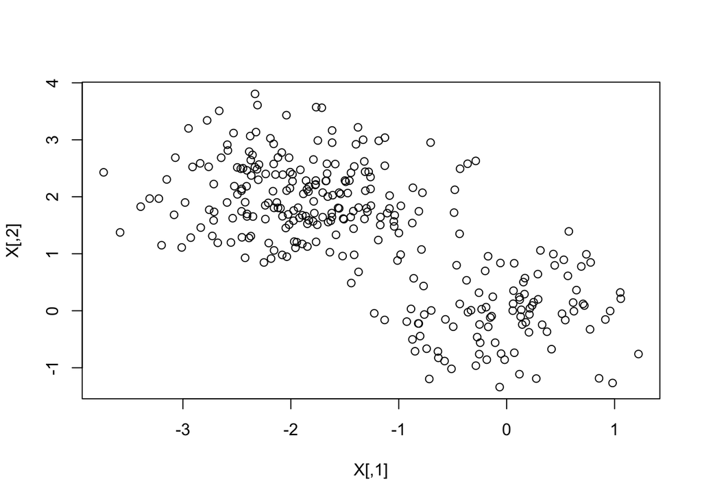

```r
X = rbind(rmvnorm(100,c(0,0),0.4*diag(2)),
          rmvnorm(200,c(-2,2),0.4*diag(2)))
plot(X)
```

```r
out = Mclust(X,G = 2)
```

```r
# Diaplaying the estimated proportions
out$parameters$pro
```

```
## [1] 0.3289108 0.6710892
```

```r
# Displaying the group means (in columns!)
out$parameters$mean
```

```
##             [,1]      [,2]
## [1,] -0.02392945 -1.926123
## [2,] -0.02994564  2.035174
```

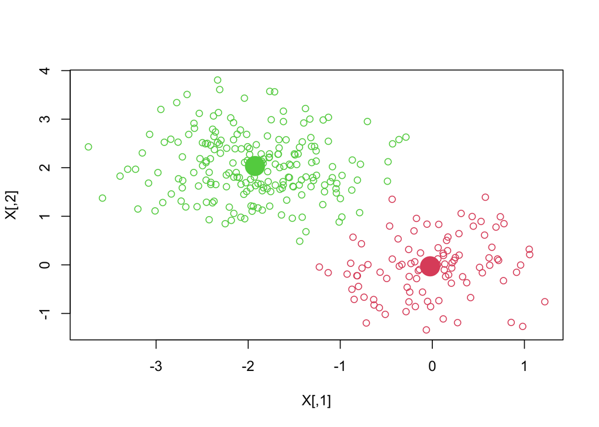

```r
plot(X,col=out$class+1)
points(t(out$parameters$mean),col=2:3,pch=19,cex=3)
```

The `mclust` package also proposes some visualization function:

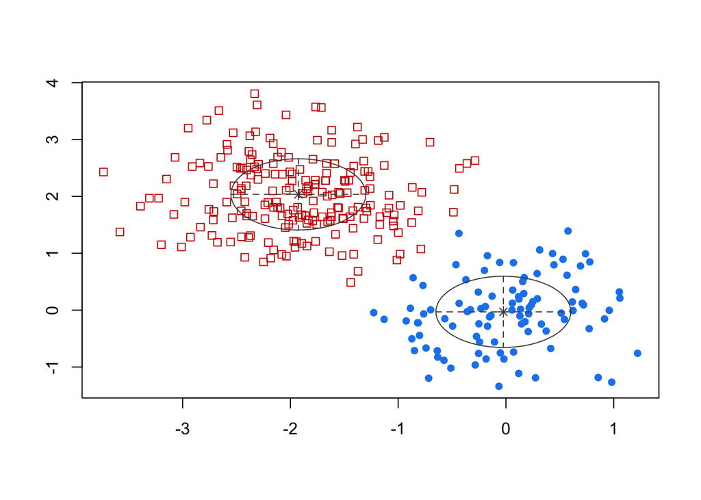

```r
plot(out,what = "classification")
```

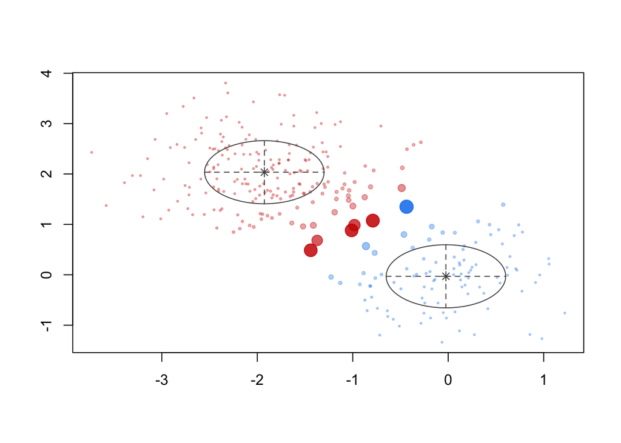

```r
plot(out,what = "uncertainty")
```

> Exercise: could you explain how this plot is produced?

This plot represents the uncertainty of missclassification of the data points, that is stored in the field `out$z`, which represents the posterior probabilities $P(Z=k|X=x_i)$ and this for $i=1,...,n$ and $k=1,...,K$.

> Exercise: examine the plot `plot(out,what='BIC')` and comment.

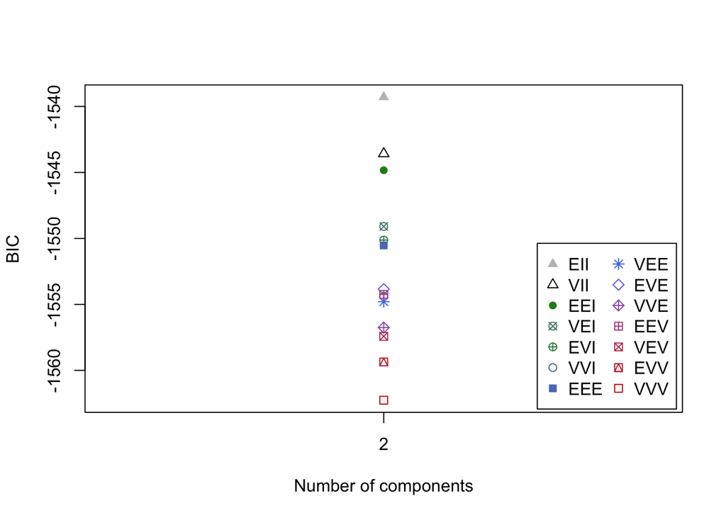

```r
plot(out,what='BIC')
```

> Exercise: use the Mclust function to try to select the best number of groups between K=1,…,5.

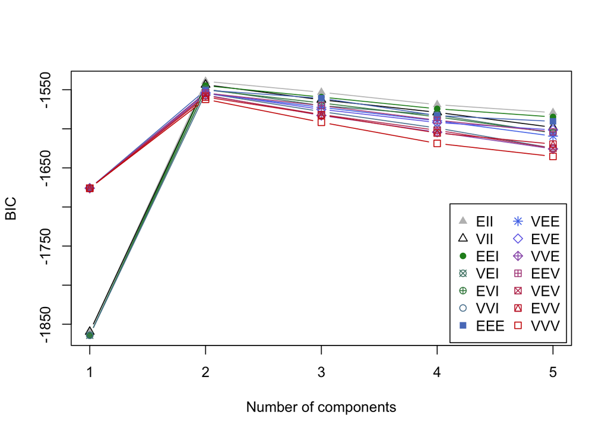

```r
out = Mclust(X,G = 1:5)
plot(out,what='BIC')
```

Here, we can see that the GMM model “EII” (i.e. kmeans) with 2 components (groups) is the best model according to BIC.

In order to see the difference in term of model selection between BIC and ICL, we can simulate the following data:

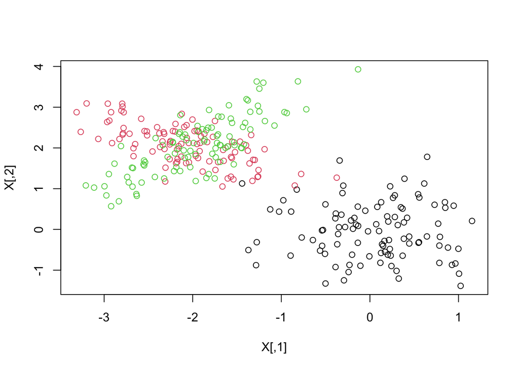

```r
X = rbind(rmvnorm(100,c(0,0),0.4*diag(2)),
          rmvnorm(100,c(-2,2),rbind(c(0.5,-0.3),c(-0.3,0.3))),
          rmvnorm(100,c(-2,2),rbind(c(0.3,0.3),c(0.3,0.5))))
cls = rep(1:3,rep(100,3))
plot(X,col=cls)
```

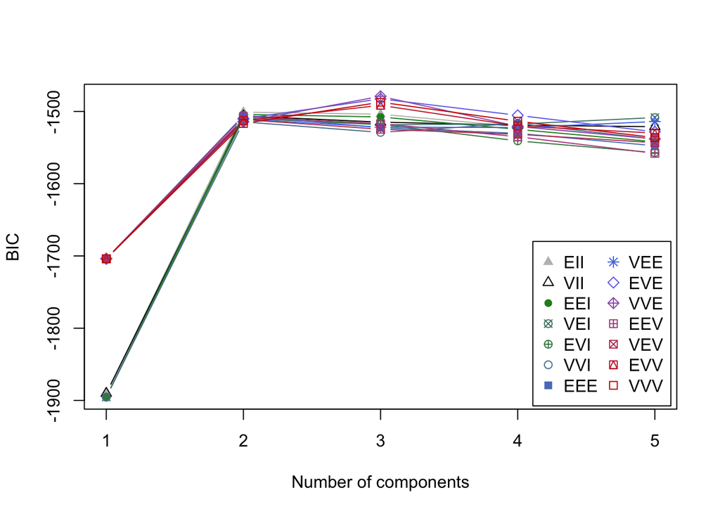

```r
out.bic = Mclust(X,G = 1:5)
plot(out.bic,what="BIC")
```

```r
out.bic
```

```
## 'Mclust' model object: (VVE,3)
##
## Available components:
##  [1] "call"           "data"           "modelName"      "n"
##  [5] "d"              "G"              "BIC"            "loglik"
##  [9] "df"             "bic"            "icl"            "hypvol"
## [13] "parameters"     "z"              "classification" "uncertainty"
```

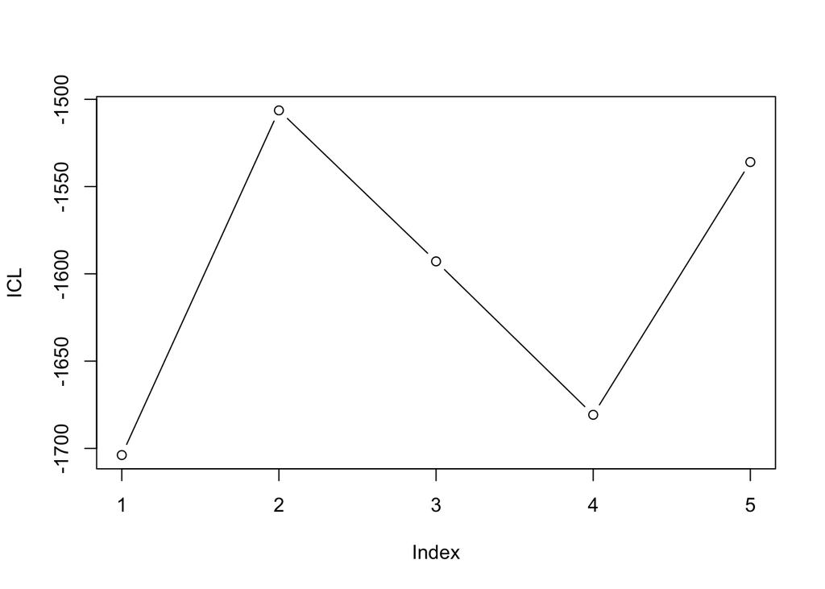

```r
ICL = c()
for (g in 1:5) ICL[g] = Mclust(X,G = g)$icl
plot(ICL,type='b')
```

Here, we can see that ICL clearly picks 2 groups whereas BIC picks 3 groups, with in addition a big uncertainty between 2 and 3 groups.

# Statistical learning in high dimensions

## The curse of dimensionality

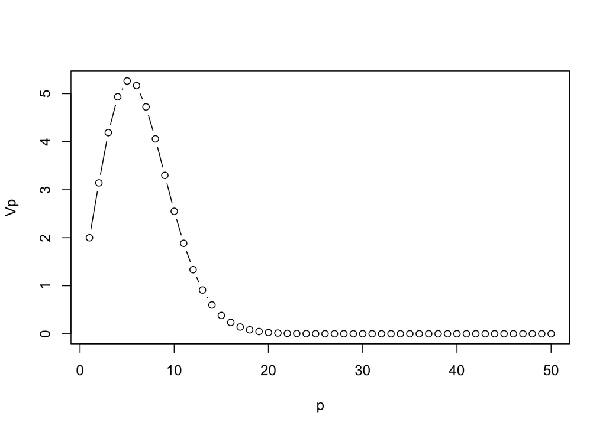

```r
p=1:50
Vp = pi^(p/2) / gamma(p/2+1)
plot(p,Vp,type='b')
```

## Subspace clustering

Let’s first load some high-dimensional data that are provided within the `MBCbook` package.

```r
#install.packages("MBCbook")
library(MBCbook)
```

Let’s consider the `usps358` data:

```r
data("usps358")
dim(usps358)
```

```
## [1] 1756  257
```

```r
Z = usps358$cls
X = usps358[,-1]
```

In `X`, we have many examples of handwritten digits of 3, 5 and 8, that are described using small images of 16x16=256 pixels.

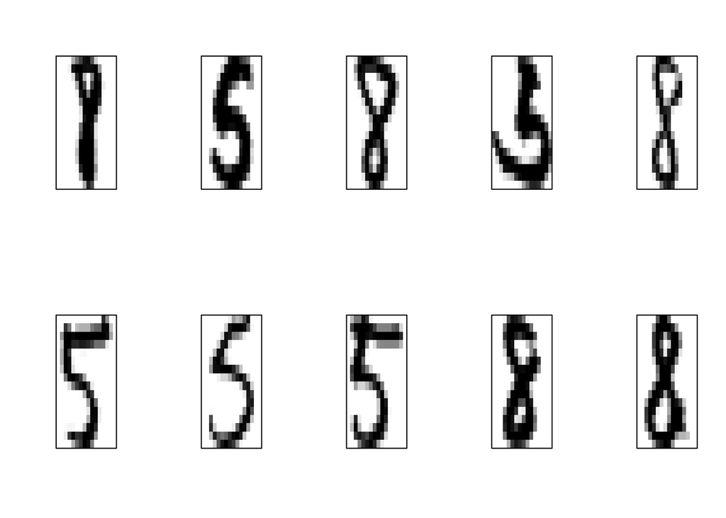

```r
plotIm <- function(x){
  image(t(matrix(t(x),ncol=16,byrow=TRUE)[16:1,]),col=gray(255:0/255),axes=F)
  box()
}

par(mfrow=c(2,5))
for (i in 1:10){
  ind = sample(nrow(X),1)
  plotIm(X[ind,])
}
```

> Exercise: cluster those data into 3 groups with kmeans and visualize the obtained group means.

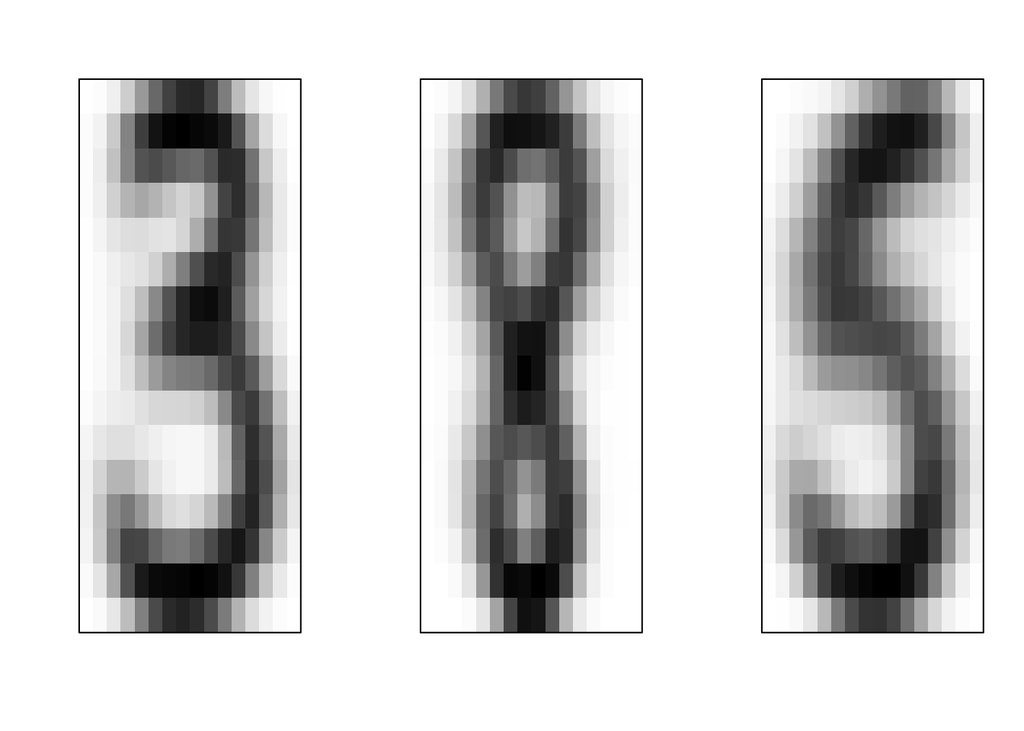

```r
out.kmeans = kmeans(X,3)
par(mfrow=c(1,3))
for (k in 1:3) plotIm(out.kmeans$centers[k,])
```

Let’s now consider the use of MPPCA / HDDC for clustering those data:

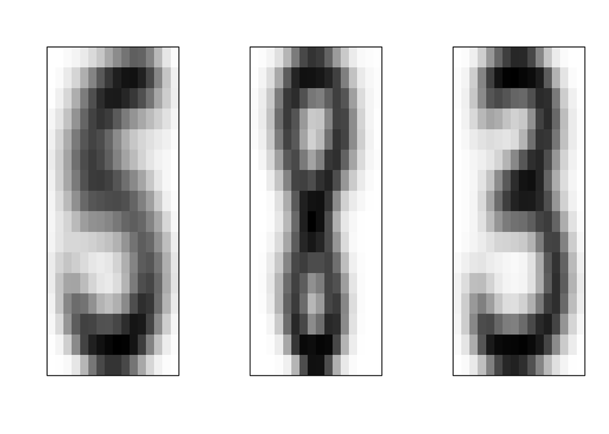

```r
#install.packages('HDclassif')
library(HDclassif)

out.hddc = hddc(X,3)
par(mfrow=c(1,3))
for (k in 1:3) plotIm(out.hddc$mu[k,])
```

It is also possible to compare the confusion matrices:

```r
# for kmeans
table(Z,out.kmeans$cluster)
```

```
##
## Z     1   2   3
##   1 561  58  39
##   2  31  57 468
##   3  33 492  17
```

```r
# for HDDC
table(Z,out.hddc$class)
```

```
##
## Z     1   2   3
##   1  45  20 593
##   2 550   2   4
##   3  22 494  26
```

It is also interesting to see how many dimensions have been used to model the different digits with HDDC:

```r
out.hddc$d
```

```
##       Intrinsic dimensions of the classes:
##        1 2 3
##   dim: 7 6 7
```